# PD 5

## 6.3 Podsumowanie

Ostatnią, dość łatwo zauważalną różnicą jest budowa drzewa i reguły decyzyjne. Po przyjrzeniu się im dokładniej można zauważyć, że domyślnym argumentem jest `gini`.

# 7 CTREE

W tym rozdziale zwięźle opiszemu różnice międzu drzewem `rpart`, a `ctree` oraz porównamy wyniki otrzymane dzięki obu tym algorytmom w naszym problemie.

## 7.1 Opis różnicy w działaniu

Podstawową różnicą pomiędzy `ctree`, a `rpart` jest to jakie zmienne są wybierane do podziału oraz to jak są dzielone. Klasyczne drzewa z `rpart` robią tak, żeby zmaksymalizować przyrost informacji, można wybrać jakiej, nawet robiliśmy to w tej pracy domowej. Natomiast `ctree` mają troche inne podejście, sprawdza poziom istotności różnych i permutacji podziału. Widać, że jest to znacząca różnica, może ona wpływać na to jakie wyniki będzie dawał konkretny algorytm.

## 7.2 Porównanie wydajności

Spójrzmy jeszcze raz jakie wartości liczbowe uzyskiwał nasz najlepszy model.

```r
perf_classif_art
```

```
##       auc       acc
## 0.7753661 0.7874794
```

Teraz porównajmy to z tym jak spisuje się model oparty o `ctree`.

```r
perf_classif_ctree
```

```
##       auc       acc
## 0.7934529 0.7808896
```

## 7.3 Drzewo decyzyjne

Zobaczmy jak będzie wyglądać to drzewo.

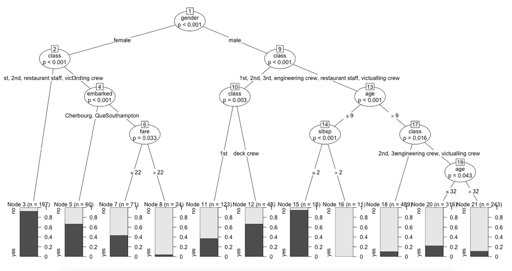

```r
knitr::include_graphics("3.png")
```

## 7.4 Podsumowanie

Widać, że model `rpart` dał minimalnie wyższe `acc`, natomiast `ctree` dał już znacząco większe `auc`, można z tego wnioskować, że dla tego problemu lepiej jest używać `ctree`. Szczególnie należy się nad tym zastanowić, ponieważ tu porównaliśmy model (`ctree`) z domyślnie ustawionymi hiperparamterami, więc należałoby sprawdzić randomowym szukaniem najlepsze parametry.

# 8 PS

Poszukajmy najlepszych parametrów dla `ctree` i sprawdźmy jak się on z nimi spisuje. Będziemy to robić metodą random search dla 2000 prób. Dla równowagi też będziemy tuningować 4 hiperparametry:

- `minsplit` - minimalna “masa”, aby rozważać dzielenie węzła,
- `minbucket` - minimalna “masa” w liściu drzewa,
- `mincriterion` - statystyka musi przekroczyć te wartość, aby było rozważane dzielenie,
- `maxdepth` - maksymalna głębokość drzewa (0 = brak ograniczeń).

Widzimy zatem, że hiperparametry są bardzo analogiczne do tych z `rpart`.Sprawdźmy zatem jak poradzi sobie model ze znalezionymi hiperparametrami.

```r
perf_classif_ctree_best
```

```
##       auc       acc
## 0.7969753 0.7792422
```

Widać, że udało nam się zwiększyć `auc`, przy większej mocy obliczeniowej prawdopodobnie dałoby się znaleźć jeszcze lepszy zestaw paramterów.